# Reproducible Research

## Week 1

Workbook for videos for "Structure of a Data Analysis".

Question/Objective: Can we use quantitative characteristics of emails to classify them as SPAM in an automated way?

Will be downloading and using an existing dataset from the library `kernlab`.

```r
library(kernlab)
data(spam)
```

Next we perform subsampling to split the dataset into two groups: train and test:

```r
set.seed(3435)
trainIndicator = rbinom(4601, size=1, prob=0.5)
table(trainIndicator)
```

```
## trainIndicator
##    0    1
## 2314 2287
```

```r
trainSpam = spam[trainIndicator == 1, ]
testSpam = spam[trainIndicator == 0, ]

knitr::kable(head(trainSpam))
```

|  | make | address | all | num3d | our | over | remove | internet | order | mail | receive | will | people | report | addresses | free | business | email | you | credit | your | font | num000 | money | hp | hpl | george | num650 | lab | … |
| --- | --- | --- | --- | --- | --- | --- | --- | --- | --- | --- | --- | --- | --- | --- | --- | --- | --- | --- | --- | --- | --- | --- | --- | --- | --- | --- | --- | --- | --- | --- |
| 1 | 0.00 | 0.64 | 0.64 | 0 | 0.32 | 0.00 | 0.00 | 0 | 0.00 | 0.00 | 0.00 | 0.64 | 0.00 | 0 | 0 | 0.32 | 0 | 1.29 | 1.93 | 0.00 | 0.96 | 0 | 0 | 0.00 | 0 | 0 | 0 | 0 | 0 | … |
| 7 | 0.00 | 0.00 | 0.00 | 0 | 1.92 | 0.00 | 0.00 | 0 | 0.00 | 0.64 | 0.96 | 1.28 | 0.00 | 0 | 0 | 0.96 | 0 | 0.32 | 3.85 | 0.00 | 0.64 | 0 | 0 | 0.00 | 0 | 0 | 0 | 0 | 0 | … |
| 9 | 0.15 | 0.00 | 0.46 | 0 | 0.61 | 0.00 | 0.30 | 0 | 0.92 | 0.76 | 0.76 | 0.92 | 0.00 | 0 | 0 | 0.00 | 0 | 0.15 | 1.23 | 3.53 | 2.00 | 0 | 0 | 0.15 | 0 | 0 | 0 | 0 | 0 | … |
| 12 | 0.00 | 0.00 | 0.25 | 0 | 0.38 | 0.25 | 0.25 | 0 | 0.00 | 0.00 | 0.12 | 0.12 | 0.12 | 0 | 0 | 0.00 | 0 | 0.00 | 1.16 | 0.00 | 0.77 | 0 | 0 | 0.00 | 0 | 0 | 0 | 0 | 0 | … |
| 14 | 0.00 | 0.00 | 0.00 | 0 | 0.90 | 0.00 | 0.90 | 0 | 0.00 | 0.90 | 0.90 | 0.00 | 0.90 | 0 | 0 | 0.00 | 0 | 0.00 | 2.72 | 0.00 | 0.90 | 0 | 0 | 0.00 | 0 | 0 | 0 | 0 | 0 | … |
| 16 | 0.00 | 0.42 | 0.42 | 0 | 1.27 | 0.00 | 0.42 | 0 | 0.00 | 1.27 | 0.00 | 0.00 | 0.00 | 0 | 0 | 1.27 | 0 | 0.00 | 1.70 | 0.42 | 1.27 | 0 | 0 | 0.42 | 0 | 0 | 0 | 0 | 0 | … |

```r
table(trainSpam$type)
```

```
##
## nonspam    spam
##    1381     906
```

Some exploratory plots - first looking at the variable `capitalAve`, which is the average number of capitalized letters in the email. Plot this for the two groups (*note, since lots of zero values, add "1" to this value for all rows, then plot the log10).

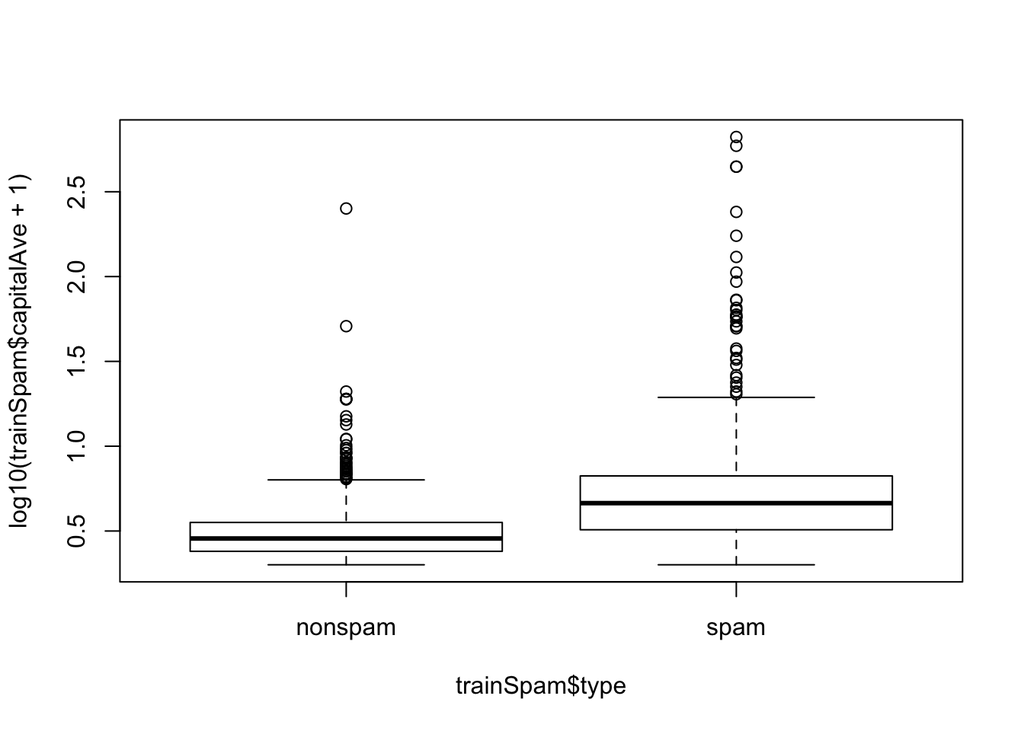

```r
plot(log10(trainSpam$capitalAve +1) ~ trainSpam$type)
```

We see that the 'spam' emails contain more capital letters than non-spam emails.

We can also make pair-wise correlation plots to examine how variables may be correlated with each other.

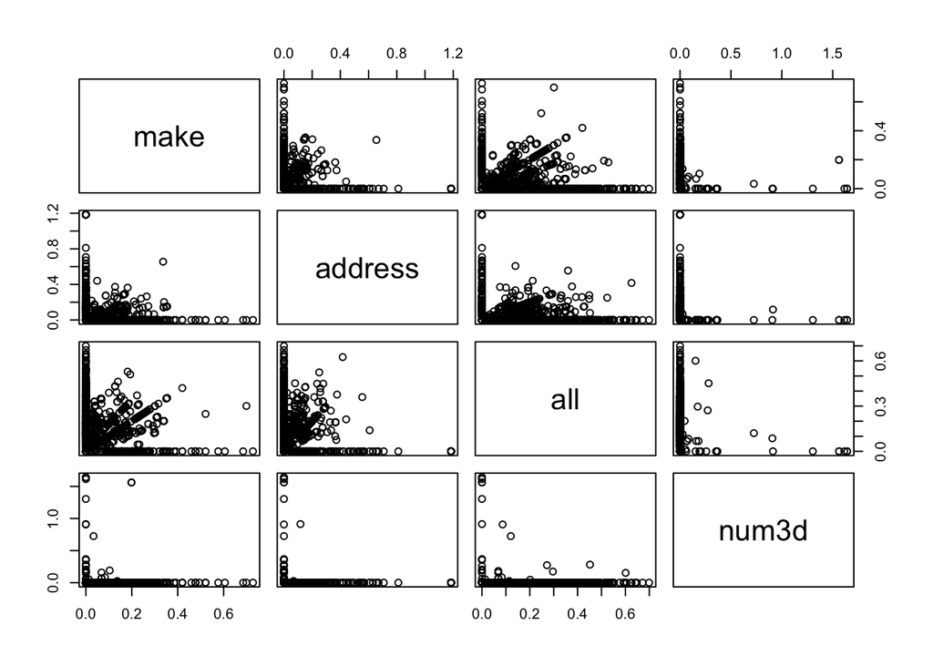

```r
plot(log10(trainSpam[ ,1:4]+1))
```

From this we can see that some variables are more correlated with each other than others. For example, `make` and `all` are more correlated than `all` and `num3d`.